# Data 607 Final Project

Joshua Registe

12/11/2019

# 1 Motivation

As part of this final project, I will be looking at weather patterns globally over the past few decades looking at potential major contributors to the cause of global warming. Engineers and scientists often get posed questions along the lines of infrastructure resiliency and protection against the effects of storms, rising sea level, air quality and water resources, all which are increasingly seeing the effects of climate change. It is important to understand his and be able to propose solutions that are feasible for the future of the planet.

[figure not shown]

Some of the data sources that will be considered include:

data.world climate data, kaggle greenhouse gas dataset containing data on containing global population, emissions, temperature, energy, etc. As well as research article data from the Sciencenews website.

data sources:  
https://data.world/worldbank/climate-change-data  
https://www.kaggle.com/unitednations/international-greenhouse-gas-emissions/data#  
https://www.sciencenews.org/

The presentation will follow OSEMN workflow for obtaining data, scrubbing data, exploring data, modeling data, and interpreting results

# 2 Library Preparation

```r
library(readxl)
library(dplyr)
library(tidyr)
library(stringr)
library(tidyverse)
library(httr)
library(rvest)
library(digest)
library(tidytext)
library(wordcloud)
library(RColorBrewer)
library(XML)
library(stringr)
library(ggplot2)
library(tm)
library(magrittr)
library(rworldmap)
library(caret)
library(rpart)
library(rpart.plot)
library(ggcorrplot)
library(Hmisc)
library(DT)
library(knitr)
```

# 3 Qualitative Analysis

## 3.1 Web Scraping

[figure not shown]

To begin, Web scraping was done with the following script to pull data from https://www.sciencenews.org/. This specific script allowed for looping through all pages of science news under the search query of “Climate Change” and “Global Warming”.

```r
ArticleListings <- data.frame(title=character(),
                              summary=character(),
                              link=character(),
                              description = character(),
                              stringsAsFactors=FALSE)

#causes of climate change searched on Science news
for (i in seq(0,40,1)){

  var<-read_html(paste0('https://www.sciencenews.org/page/',i,'?s=cause+of+climate+change&topic=&start-date=&end-date=&orderby=relevance'))
  title<-html_nodes(var,'.post-item-river__title___J3spU a') %>% html_text(trim = TRUE)
  link<-html_nodes(var,'.post-item-river__title___J3spU a') %>% html_attr('href')
  summary<-html_nodes(var,'.post-item-river__excerpt___3ok6B') %>% html_text(trim = TRUE)


  ArticleListingstemp <- data.frame(title=character(),
                                    summary=character(),
                                    link=character(),
                                    stringsAsFactors=FALSE)

  ArticleListingstemp <- rbind(ArticleListingstemp, as.data.frame(cbind(title,
                                                                        summary,
                                                                        link)))

  ArticleListings<- bind_rows(ArticleListings,ArticleListingstemp)

}

#causes of global warming searched on science articles

for (i in seq(0,40,1)){

  var<-read_html(paste0('https://www.sciencenews.org/page/',i,'?s=cause+of+global+warming&topic=&start-date=&end-date=&orderby=relevance'))
  title<-html_nodes(var,'.post-item-river__title___J3spU a') %>% html_text(trim = TRUE)
  link<-html_nodes(var,'.post-item-river__title___J3spU a') %>% html_attr('href')
  summary<-html_nodes(var,'.post-item-river__excerpt___3ok6B') %>% html_text(trim = TRUE)

  ArticleListingstemp <- data.frame(title=character(),
                                    summary=character(),
                                    link=character(),
                                    stringsAsFactors=FALSE)

  ArticleListingstemp <- rbind(ArticleListingstemp, as.data.frame(cbind(title,
                                                                        summary,
                                                                        link)))

  ArticleListings<- bind_rows(ArticleListings,ArticleListingstemp)
  }

for (i in 1:nrow(ArticleListings)){

  ArticleListings[i,4]<- read_html(ArticleListings[i,3])%>%html_nodes('.single__rich-text___BlzVF p')%>% html_text()%>%paste(collapse = " ")
}
rm(ArticleListingstemp)
```

```r
datatable(ArticleListings[c(1:4)])
```

|  | X | title | summary | link |
| --- | --- | --- | --- | --- |
| 1 | 1 | Is climate change causing Europe’s intense heat? A scientist weighs in | Science News talks with climate scientist Karsten Haustein about attributing extreme heat events in Europe and South Asia to climate change. | https://www.sciencenews.org/article/climate-change-europe-heat-wave |
| 2 | 2 | Why this warmer world is not just a passing phase | Editor in Chief Nancy Shute discusses climate change and the uncertainty of science. | https://www.sciencenews.org/article/why-warmer-world-not-just-passing-phase |
| 3 | 3 | How climate change is already altering oceans and ice, and what’s to come | A new IPCC report gives the lowdown on how climate change is already wreaking havoc on Earth’s oceans and frozen regions, and how much worse things could get. | https://www.sciencenews.org/article/ipcc-how-climate-change-already-altering-oceans-ice-future |
| 4 | 4 | Climate change could raise the risk of deadly fungal infections in humans | The rise of Candida auris, a deadly fungus spurring outbreaks in the United States and worldwide, may have been aided by climate change. | https://www.sciencenews.org/article/climate-change-could-raise-risk-deadly-fungal-infections-humans |
| 5 | 5 | 50 years ago, scientists puzzled over a slight global cooling | Five decades ago, scientists were puzzled over a slight dip in global temperatures. Today we know it was just a blip, and that Earth’s climate is warming thanks to industrial activity over the last ce… | https://www.sciencenews.org/article/50-years-ago-scientists-puzzled-over-slight-global-cooling |
| 6 | 6 | Climate change may be throwing coral sex out of sync | Several widespread corals in the Red Sea are flubbing cues to spawn en masse. | https://www.sciencenews.org/article/climate-change-throwing-coral-sex-out-sync |
| 7 | 7 | Drug-resistant microbes kill about 35,000 people in the U.S. per year | The latest CDC report on drug-resistant microbes finds that these pathogens infect close to 3 million people in the United States each year. | https://www.sciencenews.org/article/cdc-drug-resistant-microbes-kill-about-35000-people-united-states-per-year |
| 8 | 8 | Climate change may make El Niño and La Niña less predictable | Atlantic Niñas and Niños have been fairly reliable bellwethers for severe El Niño and La Niña events in the Pacific. A warming world may change that. | https://www.sciencenews.org/article/climate-change-may-make-el-nino-la-nina-less-predictable |
| 9 | 9 | Nepal is reeling from an unprecedented dengue outbreak | As climate change opens new regions to mosquitoes, Nepal suffers an outbreak of the painful viral disease that has sickened more than 9,000 people. | https://www.sciencenews.org/article/nepal-reeling-from-unprecedented-dengue-virus-outbreak |
| 10 | 10 | Climate misinformation may be thriving on YouTube, a social scientist warns | Analyzing 200 climate-related videos on YouTube shows that a majority challenge widely accepted views about climate change and climate engineering. | https://www.sciencenews.org/article/climate-misinformation-may-be-thriving-youtube-social-scientist-warns |

[output cut: 821 more lines]

We can create a function as shown in the following code to allow us to do a word cloud on any of the fields from dataset’s column. With our webscraped dataset from https://www.sciencenews.org/, 3 word clouds were generated for the title of the articles, the summary of the articles, and the articles themselves from every link extracted into the dataframe. This allows us to visualize the patterns in words associated with “climate change” and “global warming” searches. Within these word clouds, sentimental words (words that describe feelings and emotions), and stop words (words that appear frequently such as “a” in the english language).

## 3.2 Text Visualization

```r
wordextract<- function(dfcolumn){
descriptionwords <- dfcolumn %>% str_replace_all("^<[:graph:]*>$","")%>%
  str_replace_all("\\\n"," ") %>%
  str_replace_all("[^[:alpha:] ]"," ") %>% str_replace_all("\\s[:alpha:]{1,2}\\s","")%>% tolower()

#pulling all individual words into a dataframe and counting
word_counts <- as.data.frame(table(unlist(strsplit(descriptionwords, "\\s+"))))
colnames(word_counts)<-c("word","Freq")
#removing filler words and sentimental words
word_counts <-anti_join(word_counts,get_stopwords())%>%
  anti_join(get_sentiments())
wordcloud(words = word_counts$word, freq = word_counts$Freq, min.freq = 1,
          max.words=100, random.order=FALSE, rot.per=0.35,
          colors=brewer.pal(8, "Dark2"))

}
```

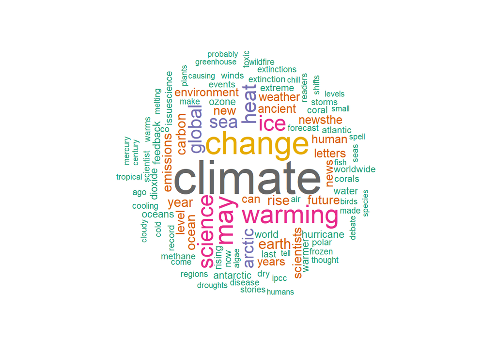

```r
wordextract(ArticleListings$title)
```

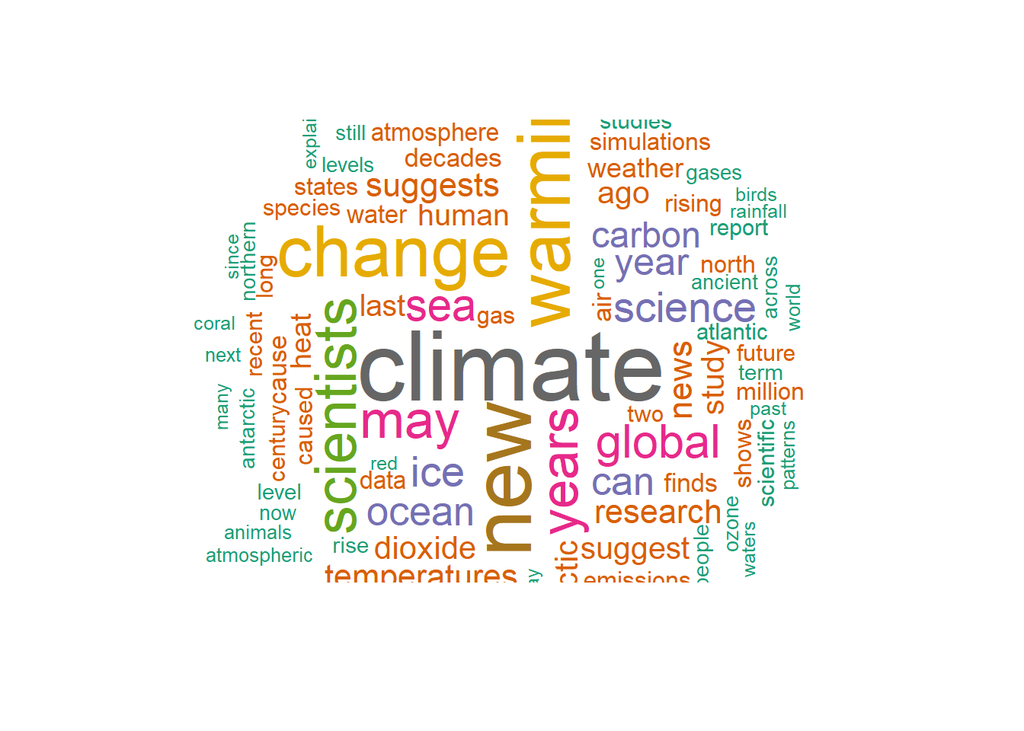

```r
wordextract(ArticleListings$summary)
```

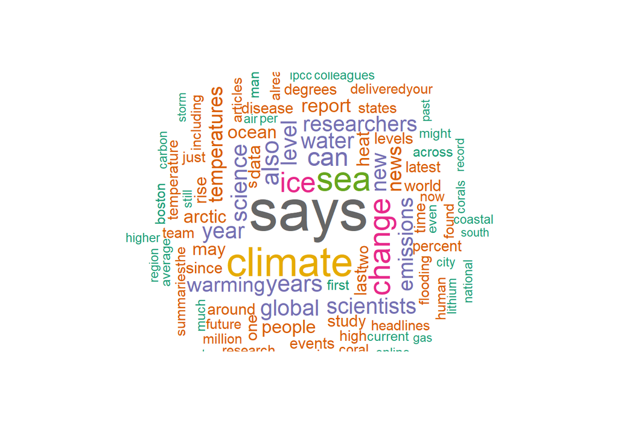

```r
wordextract(ArticleListings$description)
```

We can clearly see some of the words associated with climate change such as: emissions, sea level rise, carbon, earth, ocean, environment, arctic, oceans, droughts, tides, etc. these words represent both causes and effects of climate change.

# 4 Quantitative Analyses 1

## 4.1 Data Collection

[figure not shown]

Diving deeper into more quantitative analyses, a dataset from data.world was extracted look at the greenhouse gas emissions world wide.

https://data.world/worldbank/climate-change-data

```r
GHG_Inventory<- read_csv("greenhouse_gas_inventory_data_data.csv")
GHG_unique_cat<-unique(GHG_Inventory$category)
GHG_unique_loc<-unique(GHG_Inventory$country_or_area)
GHG_unique_cat
```

```
##  [1] "carbon_dioxide_co2_emissions_without_land_use_land_use_change_and_forestry_lulucf_in_kilotonne_co2_equivalent"
##  [2] "greenhouse_gas_ghgs_emissions_including_indirect_co2_without_lulucf_in_kilotonne_co2_equivalent"
##  [3] "greenhouse_gas_ghgs_emissions_without_land_use_land_use_change_and_forestry_lulucf_in_kilotonne_co2_equivalent"
##  [4] "hydrofluorocarbons_hfcs_emissions_in_kilotonne_co2_equivalent"
##  [5] "methane_ch4_emissions_without_land_use_land_use_change_and_forestry_lulucf_in_kilotonne_co2_equivalent"
##  [6] "nitrogen_trifluoride_nf3_emissions_in_kilotonne_co2_equivalent"
##  [7] "nitrous_oxide_n2o_emissions_without_land_use_land_use_change_and_forestry_lulucf_in_kilotonne_co2_equivalent"
##  [8] "perfluorocarbons_pfcs_emissions_in_kilotonne_co2_equivalent"
##  [9] "sulphur_hexafluoride_sf6_emissions_in_kilotonne_co2_equivalent"
## [10] "unspecified_mix_of_hydrofluorocarbons_hfcs_and_perfluorocarbons_pfcs_emissions_in_kilotonne_co2_equivalent"
```

## 4.2 Data Cleansing

[figure not shown]

```r
{
GHG_Inventory$category<- GHG_Inventory$category %>% str_replace_all(GHG_unique_cat[[2]],"GHG_Emissions")
GHG_Inventory$category<- GHG_Inventory$category %>% str_replace_all(GHG_unique_cat[[1]],"CO2_Emissions")
GHG_Inventory$category<- GHG_Inventory$category %>% str_replace_all(GHG_unique_cat[[3]],"GHGEmissions_W/O_LULUCF")
GHG_Inventory$category<- GHG_Inventory$category %>% str_replace_all(GHG_unique_cat[[4]],"HFC_Emissions")
GHG_Inventory$category<- GHG_Inventory$category %>% str_replace_all(GHG_unique_cat[[5]],"CH4_Emissions")
GHG_Inventory$category<- GHG_Inventory$category %>% str_replace_all(GHG_unique_cat[[6]],"NF3_Emissions")
GHG_Inventory$category<- GHG_Inventory$category %>% str_replace_all(GHG_unique_cat[[7]],"N2O_Emissions")
GHG_Inventory$category<- GHG_Inventory$category %>% str_replace_all(GHG_unique_cat[[8]],"PFC_Emissions")
GHG_Inventory$category<- GHG_Inventory$category %>% str_replace_all(GHG_unique_cat[[9]],"SF6_Emissions")
GHG_Inventory$category<- GHG_Inventory$category %>% str_replace_all(GHG_unique_cat[[10]],"HFC\\+PFC")
}
GHG_unique_cat<-unique(GHG_Inventory$category)
GHG_unique_cat
```

```
##  [1] "CO2_Emissions"
##  [2] "GHG_Emissions"
##  [3] "GHGEmissions_W/O_LULUCF"
##  [4] "HFC_Emissions"
##  [5] "CH4_Emissions"
##  [6] "NF3_Emissions"
##  [7] "N2O_Emissions"
##  [8] "PFC_Emissions"
##  [9] "SF6_Emissions"
## [10] "unspecified_mix_of_hydrofluorocarbons_hfcs_and_PFC_Emissions"
```

```r
GHG_Inventoryfreq<-GHG_Inventory %>%filter(category==GHG_unique_cat[[1]]) %>%
  group_by(country_or_area)%>%
  mutate(percbyloc=value/sum(value))
```

[figure not shown]

```r
map.world<-map_data("world")

GHG_Inventoryfreq$country_or_area<- str_replace_all(GHG_Inventoryfreq$country_or_area,"Russian Federation","Russia" )
GHG_Inventoryfreq$country_or_area<- str_replace_all(GHG_Inventoryfreq$country_or_area,"United Kingdom","UK" )
GHG_Inventoryfreq$country_or_area<- str_replace_all(GHG_Inventoryfreq$country_or_area,"United States of America","USA" )
map.world2<-left_join(map.world, GHG_Inventoryfreq, by=c('region'='country_or_area'))

ggplot()+
 theme(legend.title = element_text("Percent"))+
 geom_map(data=map.world2, map=map.world2, aes(map_id=region, x=long, y=lat, fill=percbyloc))+
 scale_fill_gradient(low = "lightblue",high = "purple", guide = "colourbar")+
 coord_equal()+
  labs(x = "Latitude",
       y = 'Longitude',
       title = 'Percent of Global CO2 Emissions by Country')
```

[figure not shown]

```r
GHG_Inventory%>%
  filter(country_or_area==GHG_unique_loc[1])%>%
  ggplot()+
  geom_point(mapping = aes(year,value, color = category))+geom_smooth(mapping = aes(year,value, color = category))+
  facet_wrap(category~.,scales='free_y')+

  theme(strip.text.x=element_blank(),legend.position = 'bottom', axis.text.x = element_text(angle = 90))+
  labs(title = "U.S. Greenhouse Gas Emissions Over Time",
       x = "Eq Metric Tons CO2",
       y = "Year")
```

# 5 Quantitative Analyses 2

## 5.1 Data Collection and Cleaning

To dive deeper into the causes of climate change, a dataset from https://www.kaggle.com/unitednations/international-greenhouse-gas-emissions/data# was used which has has information on population, greenhouse gas emissions, energy, temperature and more.

This dataset in its native form was extracted in a wide format with years as columns. To perform the analyses we intend, we will need to get our data into a long format for the years, and then re-spread the data based on “Series Name” which represent the potential causes of climate change. This spreading of the data will allow us to compute pairwise comparisons greenhouse gas emissions to other factors.

```r
climatechange<-read_excel("climate_change_download_0.xls")

#convert to long
climatechange_gather<-climatechange%>%gather(key = "DATE",value = "VALUE",-(1:6),(7:ncol(climatechange)))

climatechangeunique<-unique(climatechange_gather$`Series name`)
climatechange_gather<-climatechange_gather[c(2,4,7,8)]
climatechange_gather$VALUE<-as.numeric(climatechange_gather$VALUE)

ClimatechangeUS<-climatechange_gather%>%filter(`Country name`=="United States")
```

The first analysis that was done was a dendrogram computing a classification of CO2 emissions based on the other 60 parameters in the dataset. CO2 emissions was converted into a classification problem where quartiles were used to provide level of risk associated with climate change:  
1 - Low risk  
2 - Low/medium risk  
3 - Medium/high risk  
4 - High risk

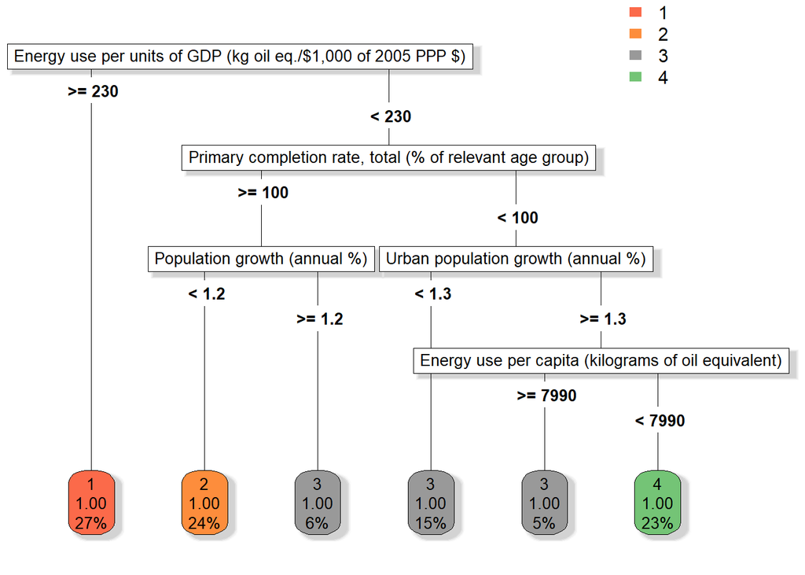

```r
ClimatechangeUSTree<- ClimatechangeUS %>% spread(`Series name`,VALUE)


ClimatechangeUSTree$CO2Thresh<-as.factor(
ntile(ClimatechangeUSTree$`CO2 emissions, total (KtCO2)`, 4))


ClimatechangeUSMatrix<-ClimatechangeUSTree[c(-1,-2,-13,-14)]

ClimatechangeUSTree<-ClimatechangeUSTree[c(-1,-2,-13,-14,-15)]


ClimatechangeUSTree <- ClimatechangeUSTree[,colSums(is.na(ClimatechangeUSTree))<nrow(ClimatechangeUSTree)-5]

ClimatechangeUSTree<- ClimatechangeUSTree%>%filter(is.na(CO2Thresh)==FALSE)

ClimatechangeUSTreeS<- sample_n(ClimatechangeUSTree,1000,replace= TRUE)

SingleTree <- rpart(formula = CO2Thresh ~ .,
                    data = ClimatechangeUSTreeS,
                    method = 'class')

rpart.plot(x = SingleTree, yesno = 2, type = 5,extra = 108,tweak = 1, shadow.col = "lightgrey")
```

Finally, We can write a function to create a pairwise correlation matrix of all the parameters in our dataset and look at spearman regression coefficients to see which of our parameters have strong monotonic (increasing or decreasing coincidentally) relationships with CO2 emissions. We can see from the figure below that some of the parameters with the strongest relationship to CO2 emissions include:  
Energy consumption  
Population

```r
Pearson_Matrix<-function(Data,siglevel,statmethod,labsize){
  #get all the numeric data out for meatrix
  Data<-select(Data,which(sapply(Data,class)=="numeric"))
  cor_data<- rcorr(as.matrix(Data),type = statmethod)
  M <- cor_data$r
  #p to designate significant correlations
  p_mat <- cor_data$P

  for(i in 1:ncol(Data)){
    try(p_mat[i,i]<-0)
  }
    Matrix<-ggcorrplot(M,method = "square", colors = c("#E46726", "white","#6D9EC1"),lab = TRUE,
                     lab_size = labsize,type = "full", p.mat=p_mat, sig.level = siglevel,legend.title = statmethod,
                     title = paste0(statmethod," Correlation Matrix" ))
  print(Matrix)
}
```

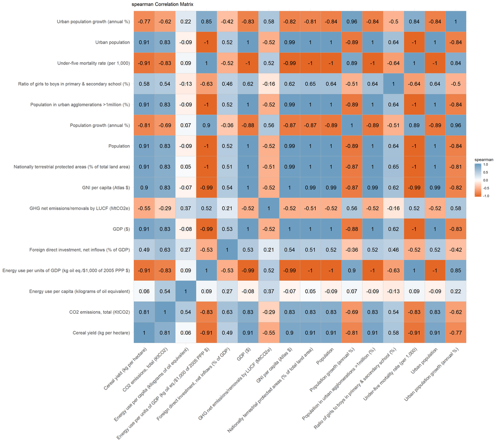

```r
ClimatechangeUSMatrix<- ClimatechangeUSMatrix[-length(ClimatechangeUSMatrix)]
ClimatechangeUSMatrix <- ClimatechangeUSMatrix[,colSums(is.na(ClimatechangeUSMatrix))<nrow(ClimatechangeUSMatrix)-15]

ClimatechangeUSTreeS<- sample_n(ClimatechangeUSTree,100,replace= TRUE)
Pearson_Matrix(ClimatechangeUSMatrix,.05,"spearman",5)
```

# 6 Conclusion

There is an extensive library on all things related to climate change and this project barely scratches the surface, however we are able to portray just how valuable some of the tools within R can be for:  
Webscraping - Using packages such as rvest to perform text-based analyses on science related articles on the subject of interest.  
Data collection and cleaning - Using packages such as dplyr, tidyr and stringr to to maniputlate data in a form that would allow us perform certain analyses and visualisations  
Analysis and Visualisation - Using packages within the tidyverse to perform highly customizable visualisations as well as packages Hmisc and r.part and ggcorrplot to perform different pairwise analyses.  
We were able to look into many of the contributing factors associated with greenhouse gas emissions and climate change as well as come up with preliminary assessments on level of impacts for all of these parameters.